# Problem Statement:

Census-income data plays the most important role in the democratic system of government, highly affecting the economic sectors. Census-related figures are used to allocate federal funding by the government to different states and localities. Census data is also used for post census residents estimates and predictions, economic and social science research, and many other such applications. Therefore, the importance of this data and its accurate predictions is very clear to us. The main aim is to increase awareness about how the income factor actually has an impact not only on the individual lives of citizens but also an effect on the nation and its betterment. You will have a look at the data pulled out from the 1994 Census bureau database, and try to find insights into how various features have an effect on the income of an individual. The data contains approximately 32,000 observations with over 15 variables. The strategy is to analyze the data and perform a predictive task of classification to predict whether an individual makes over 50K a year or less by using a logistic regression algorithm.

```python
import numpy as np
import pandas as pd
import matplotlib.pyplot as plt
import seaborn as sns
from sklearn import metrics
from sklearn.preprocessing import StandardScaler
from sklearn.model_selection import train_test_split
from sklearn.linear_model import LogisticRegression
```

```python
df=pd.read_csv('census-income .csv')
```

```python
df.head()
```

|  | age | workclass | fnlwgt | education | education-num | marital-status | occupation | relationship | race | sex | capital-gain | capital-loss | hours-per-week | native-country | annual_income |
| --- | --- | --- | --- | --- | --- | --- | --- | --- | --- | --- | --- | --- | --- | --- | --- |
| 0 | 39 | State-gov | 77516 | Bachelors | 13 | Never-married | Adm-clerical | Not-in-family | White | Male | 2174 | 0 | 40 | United-States | <=50K |
| 1 | 50 | Self-emp-not-inc | 83311 | Bachelors | 13 | Married-civ-spouse | Exec-managerial | Husband | White | Male | 0 | 0 | 13 | United-States | <=50K |
| 2 | 38 | Private | 215646 | HS-grad | 9 | Divorced | Handlers-cleaners | Not-in-family | White | Male | 0 | 0 | 40 | United-States | <=50K |
| 3 | 53 | Private | 234721 | 11th | 7 | Married-civ-spouse | Handlers-cleaners | Husband | Black | Male | 0 | 0 | 40 | United-States | <=50K |
| 4 | 28 | Private | 338409 | Bachelors | 13 | Married-civ-spouse | Prof-specialty | Wife | Black | Female | 0 | 0 | 40 | Cuba | <=50K |

1. How many types of occupations do we have? a. 13 b. 14 c. 15 d. 11

Ans c. 15 ( counting ?) otherwise a. 14

```python
df.columns
```

```
Index(['age', 'workclass', 'fnlwgt', 'education', 'education-num',
       'marital-status', 'occupation', 'relationship', 'race', 'sex',
       'capital-gain', 'capital-loss', 'hours-per-week', 'native-country',
       'annual_income'],
      dtype='object')
```

```python
df.info()
```

```
<class 'pandas.core.frame.DataFrame'>
RangeIndex: 32561 entries, 0 to 32560
Data columns (total 15 columns):
 #   Column          Non-Null Count  Dtype
---  ------          --------------  -----
 0   age             32561 non-null  int64
 1   workclass       32561 non-null  object
 2   fnlwgt          32561 non-null  int64
 3   education       32561 non-null  object
 4   education-num   32561 non-null  int64
 5   marital-status  32561 non-null  object
 6   occupation      32561 non-null  object
 7   relationship    32561 non-null  object
 8   race            32561 non-null  object
 9   sex             32561 non-null  object
 10  capital-gain    32561 non-null  int64
 11  capital-loss    32561 non-null  int64
 12  hours-per-week  32561 non-null  int64
 13  native-country  32561 non-null  object
 14  annual_income   32561 non-null  object
dtypes: int64(6), object(9)
memory usage: 3.7+ MB
```

```python
df['occupation'].unique()
```

```
array(['Adm-clerical', 'Exec-managerial', 'Handlers-cleaners',
       'Prof-specialty', 'Other-service', 'Sales', 'Craft-repair',
       'Transport-moving', 'Farming-fishing', 'Machine-op-inspct',
       'Tech-support', '?', 'Protective-serv', 'Armed-Forces',
       'Priv-house-serv'], dtype=object)
```

1. How many people are working as tech support and have an annual income greater than 50k? a. 278 b. 389 c. 289 d. 934

```python
df['annual_income']
```

```
0        <=50K
1        <=50K
2        <=50K
3        <=50K
4        <=50K
         ...
32556    <=50K
32557     >50K
32558    <=50K
32559    <=50K
32560     >50K
Name: annual_income, Length: 32561, dtype: object
```

```python
df.loc[(df['occupation']=='Tech-support') & (df['annual_income']==">50K")]
```

|  | age | workclass | fnlwgt | education | education-num | marital-status | occupation | relationship | race | sex | capital-gain | capital-loss | hours-per-week | native-country | annual_income |
| --- | --- | --- | --- | --- | --- | --- | --- | --- | --- | --- | --- | --- | --- | --- | --- |
| 25 | 56 | Local-gov | 216851 | Bachelors | 13 | Married-civ-spouse | Tech-support | Husband | White | Male | 0 | 0 | 40 | United-States | >50K |
| 55 | 43 | Private | 237993 | Some-college | 10 | Married-civ-spouse | Tech-support | Husband | White | Male | 0 | 0 | 40 | United-States | >50K |
| 248 | 40 | Private | 207578 | Assoc-acdm | 12 | Married-civ-spouse | Tech-support | Husband | White | Male | 0 | 1977 | 60 | United-States | >50K |
| 357 | 40 | Private | 96129 | Assoc-voc | 11 | Married-civ-spouse | Tech-support | Husband | White | Male | 0 | 0 | 40 | United-States | >50K |
| 469 | 30 | Private | 118551 | Bachelors | 13 | Married-civ-spouse | Tech-support | Wife | White | Female | 0 | 0 | 16 | United-States | >50K |
| ... | ... | ... | ... | ... | ... | ... | ... | ... | ... | ... | ... | ... | ... | ... | ... |
| 31510 | 42 | Private | 111483 | Bachelors | 13 | Married-civ-spouse | Tech-support | Husband | White | Male | 0 | 0 | 50 | United-States | >50K |
| 31653 | 25 | Private | 189656 | Bachelors | 13 | Never-married | Tech-support | Not-in-family | White | Male | 0 | 0 | 60 | United-States | >50K |
| 31807 | 51 | Self-emp-not-inc | 170086 | Bachelors | 13 | Married-civ-spouse | Tech-support | Husband | White | Male | 0 | 0 | 45 | United-States | >50K |
| 32076 | 59 | Federal-gov | 293971 | Some-college | 10 | Married-civ-spouse | Tech-support | Husband | White | Male | 0 | 0 | 40 | United-States | >50K |
| 32457 | 33 | Private | 139057 | Masters | 14 | Married-civ-spouse | Tech-support | Husband | Asian-Pac-Islander | Male | 0 | 0 | 50 | United-States | >50K |

283 rows × 15 columns

1. How many total missing values are present in the dataset? a. 4262 b. 5000 c. 5349 d. 4302

```python
df.isna().sum()
```

```
age               0
workclass         0
fnlwgt            0
education         0
education-num     0
marital-status    0
occupation        0
relationship      0
race              0
sex               0
capital-gain      0
capital-loss      0
hours-per-week    0
native-country    0
annual_income     0
dtype: int64
```

1. If there are missing values in the Marital Status column, which option among the following should be used for replacing the missing values: a. Mean b. Median c. Mode d. All of the above

Ans c.Mode

1. How many people are having private work classes and are not from the United States of America? a. 2151 b. 2300 c. 2000 d. 2190

Ans 2561

```python
df.loc[(df['workclass']=='Private') & (df['native-country']!="United-States")]
```

|  | age | workclass | fnlwgt | education | education-num | marital-status | occupation | relationship | race | sex | capital-gain | capital-loss | hours-per-week | native-country | annual_income |
| --- | --- | --- | --- | --- | --- | --- | --- | --- | --- | --- | --- | --- | --- | --- | --- |
| 4 | 28 | Private | 338409 | Bachelors | 13 | Married-civ-spouse | Prof-specialty | Wife | Black | Female | 0 | 0 | 40 | Cuba | <=50K |
| 6 | 49 | Private | 160187 | 9th | 5 | Married-spouse-absent | Other-service | Not-in-family | Black | Female | 0 | 0 | 16 | Jamaica | <=50K |
| 14 | 40 | Private | 121772 | Assoc-voc | 11 | Married-civ-spouse | Craft-repair | Husband | Asian-Pac-Islander | Male | 0 | 0 | 40 | ? | >50K |
| 15 | 34 | Private | 245487 | 7th-8th | 4 | Married-civ-spouse | Transport-moving | Husband | Amer-Indian-Eskimo | Male | 0 | 0 | 45 | Mexico | <=50K |
| 35 | 48 | Private | 242406 | 11th | 7 | Never-married | Machine-op-inspct | Unmarried | White | Male | 0 | 0 | 40 | Puerto-Rico | <=50K |
| ... | ... | ... | ... | ... | ... | ... | ... | ... | ... | ... | ... | ... | ... | ... | ... |
| 32508 | 45 | Private | 155093 | 10th | 6 | Divorced | Other-service | Not-in-family | Black | Female | 0 | 0 | 38 | Dominican-Republic | <=50K |
| 32510 | 39 | Private | 107302 | HS-grad | 9 | Married-civ-spouse | Prof-specialty | Husband | White | Male | 0 | 0 | 45 | ? | >50K |
| 32533 | 54 | Private | 337992 | Bachelors | 13 | Married-civ-spouse | Exec-managerial | Husband | Asian-Pac-Islander | Male | 0 | 0 | 50 | Japan | >50K |
| 32547 | 43 | Private | 260761 | HS-grad | 9 | Married-civ-spouse | Machine-op-inspct | Husband | White | Male | 0 | 0 | 40 | Mexico | <=50K |
| 32553 | 32 | Private | 116138 | Masters | 14 | Never-married | Tech-support | Not-in-family | Asian-Pac-Islander | Male | 0 | 0 | 11 | Taiwan | <=50K |

2561 rows × 15 columns

1. How many people are either having Annual Income(last column) less than or equal to 50k or their working hours is greater than or equal to 40 hrs: a. 23008 b. 23448 c. 29505 d. 25903

Ans 31823

```python
df.loc[(df['hours-per-week']>=40) | (df['annual_income']=="<=50K")]
```

|  | age | workclass | fnlwgt | education | education-num | marital-status | occupation | relationship | race | sex | capital-gain | capital-loss | hours-per-week | native-country | annual_income |
| --- | --- | --- | --- | --- | --- | --- | --- | --- | --- | --- | --- | --- | --- | --- | --- |
| 0 | 39 | State-gov | 77516 | Bachelors | 13 | Never-married | Adm-clerical | Not-in-family | White | Male | 2174 | 0 | 40 | United-States | <=50K |
| 1 | 50 | Self-emp-not-inc | 83311 | Bachelors | 13 | Married-civ-spouse | Exec-managerial | Husband | White | Male | 0 | 0 | 13 | United-States | <=50K |
| 2 | 38 | Private | 215646 | HS-grad | 9 | Divorced | Handlers-cleaners | Not-in-family | White | Male | 0 | 0 | 40 | United-States | <=50K |
| 3 | 53 | Private | 234721 | 11th | 7 | Married-civ-spouse | Handlers-cleaners | Husband | Black | Male | 0 | 0 | 40 | United-States | <=50K |
| 4 | 28 | Private | 338409 | Bachelors | 13 | Married-civ-spouse | Prof-specialty | Wife | Black | Female | 0 | 0 | 40 | Cuba | <=50K |
| ... | ... | ... | ... | ... | ... | ... | ... | ... | ... | ... | ... | ... | ... | ... | ... |
| 32556 | 27 | Private | 257302 | Assoc-acdm | 12 | Married-civ-spouse | Tech-support | Wife | White | Female | 0 | 0 | 38 | United-States | <=50K |
| 32557 | 40 | Private | 154374 | HS-grad | 9 | Married-civ-spouse | Machine-op-inspct | Husband | White | Male | 0 | 0 | 40 | United-States | >50K |
| 32558 | 58 | Private | 151910 | HS-grad | 9 | Widowed | Adm-clerical | Unmarried | White | Female | 0 | 0 | 40 | United-States | <=50K |
| 32559 | 22 | Private | 201490 | HS-grad | 9 | Never-married | Adm-clerical | Own-child | White | Male | 0 | 0 | 20 | United-States | <=50K |
| 32560 | 52 | Self-emp-inc | 287927 | HS-grad | 9 | Married-civ-spouse | Exec-managerial | Wife | White | Female | 15024 | 0 | 40 | United-States | >50K |

31823 rows × 15 columns

1. Which of the following methods can you use for handling outliers? a. Interquartile Range(IQR) Method b. Z Score method c. Both of the above methods d. None of the above

Ans c.Both of the above methods

1. Chi-square is used to analyze: a. Determine the relationship b/w the variables b. Compare observed results with expected results c. both a and b d. None of the above

Ans c. both a and b

1. What is VIF? a. It can detect multicollinearity b. If the VIF value is greater than 10, then there is no correlation between the independent variables c. It stands for Variance Impact Factor d. VIF is when there is no correlation between one predictor and the other predictors in a model.

Ans a. It can detect multicollinearity

10.What predict_proba will tell you? a. It will predict the class probabilities b. It will tell you the target value c. Both are correct d. None of the above

Ans a. It will predict the class probabilities

11.Logistic regression is useful for regression problems: a. True b. False

Ans False

12.In logistic regression, if the predicted logit is 0, what’s the transformed probability? a. 0.5 b. 0.05 c. Both of the above d. None of the above

Ans a. 0.5

13.Which variant of logistic regression is recommended when you have a categorical dependent variable with more than two values? a. Multiple Logistic regression b. Multinomial logistic regression c. Ordered logit regression d. Poisson regression

Ans b. Multinomial logistic regression

# Perform the following tasks for answering the remaining questions

```python
df.columns
```

```
Index(['age', 'workclass', 'fnlwgt', 'education', 'education-num',
       'marital-status', 'occupation', 'relationship', 'race', 'sex',
       'capital-gain', 'capital-loss', 'hours-per-week', 'native-country',
       'annual_income'],
      dtype='object')
```

```python
df=df.fillna(0)
```

```python
df['Annual Income']=df['annual_income']
df=df.drop('annual_income', axis=1)
df
```

|  | age | workclass | fnlwgt | education | education-num | marital-status | occupation | relationship | race | sex | capital-gain | capital-loss | hours-per-week | native-country | Annual Income |
| --- | --- | --- | --- | --- | --- | --- | --- | --- | --- | --- | --- | --- | --- | --- | --- |
| 0 | 39 | State-gov | 77516 | Bachelors | 13 | Never-married | Adm-clerical | Not-in-family | White | Male | 2174 | 0 | 40 | United-States | <=50K |
| 1 | 50 | Self-emp-not-inc | 83311 | Bachelors | 13 | Married-civ-spouse | Exec-managerial | Husband | White | Male | 0 | 0 | 13 | United-States | <=50K |
| 2 | 38 | Private | 215646 | HS-grad | 9 | Divorced | Handlers-cleaners | Not-in-family | White | Male | 0 | 0 | 40 | United-States | <=50K |
| 3 | 53 | Private | 234721 | 11th | 7 | Married-civ-spouse | Handlers-cleaners | Husband | Black | Male | 0 | 0 | 40 | United-States | <=50K |
| 4 | 28 | Private | 338409 | Bachelors | 13 | Married-civ-spouse | Prof-specialty | Wife | Black | Female | 0 | 0 | 40 | Cuba | <=50K |
| ... | ... | ... | ... | ... | ... | ... | ... | ... | ... | ... | ... | ... | ... | ... | ... |
| 32556 | 27 | Private | 257302 | Assoc-acdm | 12 | Married-civ-spouse | Tech-support | Wife | White | Female | 0 | 0 | 38 | United-States | <=50K |
| 32557 | 40 | Private | 154374 | HS-grad | 9 | Married-civ-spouse | Machine-op-inspct | Husband | White | Male | 0 | 0 | 40 | United-States | >50K |
| 32558 | 58 | Private | 151910 | HS-grad | 9 | Widowed | Adm-clerical | Unmarried | White | Female | 0 | 0 | 40 | United-States | <=50K |
| 32559 | 22 | Private | 201490 | HS-grad | 9 | Never-married | Adm-clerical | Own-child | White | Male | 0 | 0 | 20 | United-States | <=50K |
| 32560 | 52 | Self-emp-inc | 287927 | HS-grad | 9 | Married-civ-spouse | Exec-managerial | Wife | White | Female | 15024 | 0 | 40 | United-States | >50K |

32561 rows × 15 columns

```python
df.info()
```

```
<class 'pandas.core.frame.DataFrame'>
RangeIndex: 32561 entries, 0 to 32560
Data columns (total 15 columns):
 #   Column          Non-Null Count  Dtype
---  ------          --------------  -----
 0   age             32561 non-null  int64
 1   workclass       32561 non-null  object
 2   fnlwgt          32561 non-null  int64
 3   education       32561 non-null  object
 4   education-num   32561 non-null  int64
 5   marital-status  32561 non-null  object
 6   occupation      32561 non-null  object
 7   relationship    32561 non-null  object
 8   race            32561 non-null  object
 9   sex             32561 non-null  object
 10  capital-gain    32561 non-null  int64
 11  capital-loss    32561 non-null  int64
 12  hours-per-week  32561 non-null  int64
 13  native-country  32561 non-null  object
 14  Annual Income   32561 non-null  object
dtypes: int64(6), object(9)
memory usage: 3.7+ MB
```

```python
df.isnull().sum()
```

```
age               0
workclass         0
fnlwgt            0
education         0
education-num     0
marital-status    0
occupation        0
relationship      0
race              0
sex               0
capital-gain      0
capital-loss      0
hours-per-week    0
native-country    0
Annual Income     0
dtype: int64
```

```python
from sklearn.preprocessing import LabelEncoder

cat_list=[]
for col in df.columns:
    if(df[col].dtype=='object'):
        cat_list.append(col)


le=LabelEncoder()
for col in cat_list:
    df[col]=le.fit_transform(df[col])
```

```python
X=df.drop('Annual Income',axis=1)
y=df['Annual Income']
```

```python
x_train,x_test,y_train,y_test=train_test_split(X,y,test_size=0.3,random_state=42)
```

```python
sc = StandardScaler()
x_train = sc.fit_transform(x_train)
x_test = sc.transform(x_test)
```

```python
lr=LogisticRegression()
```

```python
lr.fit(x_train,y_train)
```

```
LogisticRegression()
```

```python
y_pred=lr.predict(x_test)
```

```python
acc=metrics.accuracy_score(y_pred,y_test)
```

```python
acc
```

```
0.8258777766403931
```

```python
cm=metrics.confusion_matrix(y_pred,y_test)
cm
```

```
array([[7021, 1267],
       [ 434, 1047]], dtype=int64)
```

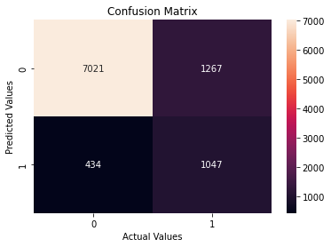

```python
plt.title('Confusion Matrix')
sns.heatmap(cm,annot = True, fmt= 'd')
plt.xlabel('Actual Values')
plt.ylabel('Predicted Values')
```

```python
clf=metrics.classification_report(y_test,y_pred)
print(clf)
```

```
              precision    recall  f1-score   support

           0       0.85      0.94      0.89      7455
           1       0.71      0.45      0.55      2314

    accuracy                           0.83      9769
   macro avg       0.78      0.70      0.72      9769
weighted avg       0.81      0.83      0.81      9769
```

14.What is the accuracy score of the above model? a. 0.60 to 0.70 b. 0.40 to 0.60 c. 0.70 to 0.85 d. None of the above Ans c. 0.70 to 0.85

16.What is the model’s precision when the target is False? a. 0.60 to 0.70 b. 0.40 to 0.60 c. 0.70 to 0.80 d. None of the above

17.What is the total support value from the above model? a. 9049 b. 9032 c. 10000 d. 9847

18.What is the f1 score of the above model when the target is True? a. 0.30 to 0.40 b. 0.40 to 0.50 c. 0.60 to 0.70 d. 0.90 to 0.99

19.How many records are correctly classified by the model? a. 7173 b. 7043 c. 7000 d. None of the above